# Lecture

Non-linear models in `inlabru`

Sara Martino

sara.martino@ntnu.no

Dept. of Mathematical Science, NTNU

Janine Illian

Janine.Illian@glasgow.ac.uk

University of Glasgow

Jafet Belmont

Jafet.Belmont@glasgow.ac.uk

University of Glasgow

## Non linear predictor

In all the models we have seen
$$\eta = \text{linear function}(\text{components})$$

- Sometimes one is interested in models whose parameters interact in a non-linear way
- A simple growth model
- Lee-Carter Model
- Under-reported counts

# A simple growth model

## A simple growth model

We want to include some “biology” in the statistical model.

The age and size of a fish have the following relationship

$$\begin{aligned}
y_t&\sim\mathcal{N}(\mu_t, \sigma^2)\\
\eta_t &= \mu_t = L(1-\exp(-k\ (t-t_0)))
\end{aligned}$$
where $t$ is the age and $y_t$ the lenght of the fish

Parameters are $\theta = c(L,\kappa, t_0)$

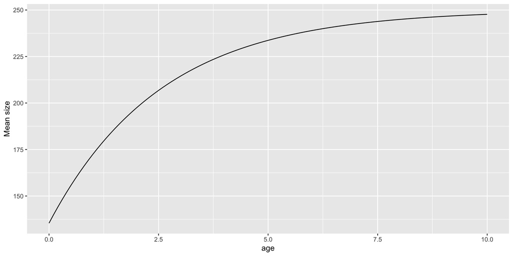

## Model Parameters and Priors

The parameters have a biological meaning and we need to assign them a prior distribution:

- $L$ is the the **maximum average length** that fish approach as they become very old.

$$L\sim\text{exp}(1/300)$$
In the prior $E(L) = 300$, $\text{sd}(L) = 300$

- $k$ is the the **growth rate** (how fast the fish grows)

$$k\sim\text{exp}(2)$$
- $t_0$ is the the **hypothetical age at zero length**

$$t_0\sim\text{exp}(1)$$

## A simple growth model - Noisy Observations

The age and size of a fish have the following relationship

$$\begin{aligned}
y_t&\sim\mathcal{N}(\mu_t, \sigma^2)\\
\eta_t &= \mu_t = L(1-\exp(-k\ (t-t_0)))
\end{aligned}$$

where $t$ is the age and $y_t$ the lenght of the fish

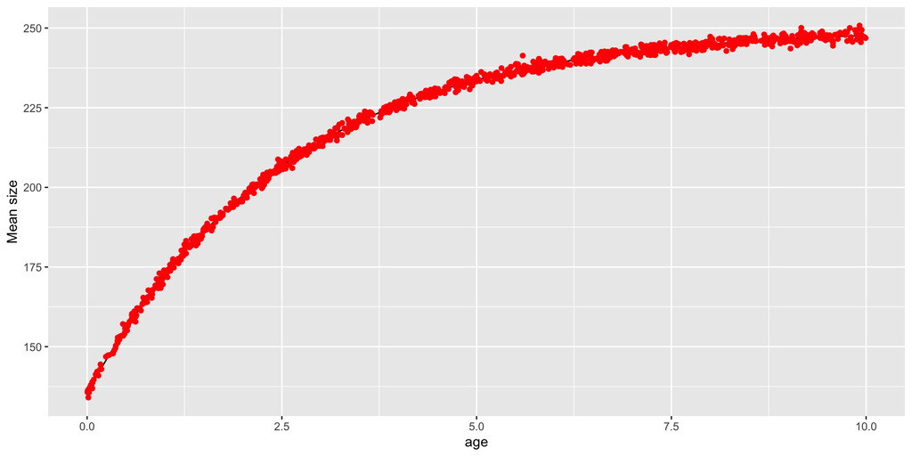

## A simple growth model

### Why do we need more than INLA?

$$\begin{aligned}
y_t&\sim\mathcal{N}(\mu_t, \sigma^2)\\
\eta_t &= \mu_t = L(1-\exp(-k\ (t-t_0)))
\end{aligned}$$

**Note** This model cannot be solved in INLA…why?

. . .

The model components $L$, $k$, $t_0$ enter the predictor $\eta$ in a non-linear way.

. . .

This means that $\eta$ is **NOT** gaussian!!

## Extending INLA to non-linear predictors

In addition to being a wrapper around R-INLA, inlabru extends the scope of INLA to models with non-linear predictors $\tilde{\eta}(\mathbf{u})$.

💡 **The idea** 💡

- Linearize $\tilde{\eta}(\mathbf{u})$ using a first-order Taylor expansion around $\mathbf{u}_0$:

$$\tilde{\eta}(\mathbf{u}) \approx \tilde{\eta}(\mathbf{u}_0) + f_{\text{linear}}(\mathbf{u}) = \bar{\eta}(\mathbf{u})$$

- Run INLA for the linearized problem
- Iterate until convergence
  - $\tilde{\eta}(\mathbf{u}_0))$ close enough to $\bar{\eta}(\mathbf{u_0})$

**Note**

**Note**

For details:  
https://arxiv.org/abs/2407.00791v1

## Extending INLA to non-linear predictors

- The linearization is an approximation on top of the “usual” INLA approximation
- Accuracy will depend on the nature of the non-linearity around $\mathbf{u}_0$ and the choice of convergence criteria.
- Greater care than usual is needed for the choice of priors.

Some checks are possible (see the arxive paper)…

**BUT** this method is still in an “experimental” mode, so great care is needed!

## A simple growth model - Fitting the model

$$\begin{align}
y_t &\sim\mathcal{N}(\eta_t,\sigma^2)\\
\eta_t &= L(1-\exp(-k(t-t_0)))\\
L &\sim\exp(1/300); \qquad k \sim\exp(2);\qquad t_0\sim\exp(1)
\end{align}$$

```r
scale_par <- sd(df$y)
df <- df %>% mutate(y_scale = y / scale_par)

cmp <- ~ -1 +
  L(1, prec.linear = 1, marginal = bm_marginal(qexp, rate = scale_par / 300)) +
  kappa(1, prec.linear = 1, marginal = bm_marginal(qexp, rate = 2)) +
  t0(1, -1, prec.linear = 1, marginal = bm_marginal(qexp, rate = 1))

growth_function <- function(L, kappa, t0, age) {
  L * (1 - exp(-kappa * (age - t0)))
}

formula <- y ~  growth_function(L, kappa, t0, age)

lik <- bru_obs(
  formula = formula,
  family = "gaussian",
  data = df
)
bru_options_set(bru_verbose = 1, bru_max_iter = 20)
fit <- bru(cmp, lik)
```

- Scale the data (always a good practice to avoid numerical problems)

## A simple growth model - Fitting the model

$$\begin{align}
y_t &\sim\mathcal{N}(\eta_t,\sigma^2)\\
\eta_t &= L(1-\exp(-k(t-t_0)))\\
L &\sim\exp(1/300); \qquad k \sim\exp(2);\qquad t_0\sim\exp(1)
\end{align}$$

```r
scale_par <- sd(df$y)
df <- df %>% mutate(y_scale = y / scale_par)

cmp <- ~ -1 +
  L(1, prec.linear = 1, marginal = bm_marginal(qexp, rate = scale_par / 300)) +
  kappa(1, prec.linear = 1, marginal = bm_marginal(qexp, rate = 2)) +
  t0(1, -1, prec.linear = 1, marginal = bm_marginal(qexp, rate = 1))

growth_function <- function(L, kappa, t0, age) {
  L * (1 - exp(-kappa * (age - t0)))
}

formula <- y ~  growth_function(L, kappa, t0, age)

lik <- bru_obs(
  formula = formula,
  family = "gaussian",
  data = df
)
bru_options_set(bru_verbose = 1, bru_max_iter = 20)
fit <- bru(cmp, lik)
```

- Define the components

**Note** here we use the PIT transform to go from $\mathcal{N}(0,1)$ to $\exp(\kappa)$

This also gives a non-linear model, this “trick” can be usedful in other cases!!

## A simple growth model - Fitting the model

$$\begin{align}
y_t &\sim\mathcal{N}(\eta_t,\sigma^2)\\
\eta_t &= L(1-\exp(-k(t-t_0)))\\
L &\sim\exp(1/300); \qquad k \sim\exp(2);\qquad t_0\sim\exp(1)
\end{align}$$

```r
scale_par <- sd(df$y)
df <- df %>% mutate(y_scale = y / scale_par)

cmp <- ~ -1 +
  L(1, prec.linear = 1, marginal = bm_marginal(qexp, rate = scale_par / 300)) +
  kappa(1, prec.linear = 1, marginal = bm_marginal(qexp, rate = 2)) +
  t0(1, -1, prec.linear = 1, marginal = bm_marginal(qexp, rate = 1))

growth_function <- function(L, kappa, t0, age) {
  L * (1 - exp(-kappa * (age - t0)))
}

formula <- y ~  growth_function(L, kappa, t0, age)

lik <- bru_obs(
  formula = formula,
  family = "gaussian",
  data = df
)
bru_options_set(bru_verbose = 1, bru_max_iter = 20)
fit <- bru(cmp, lik)
```

- Define the non-linear function of the paramters and the formula

## A simple growth model - Fitting the model

$$\begin{align}
y_t &\sim\mathcal{N}(\eta_t,\sigma^2)\\
\eta_t &= L(1-\exp(-k(t-t_0)))\\
L &\sim\exp(1/300); \qquad k \sim\exp(2);\qquad t_0\sim\exp(1)
\end{align}$$

```r
scale_par <- sd(df$y)
df <- df %>% mutate(y_scale = y / scale_par)

cmp <- ~ -1 +
  L(1, prec.linear = 1, marginal = bm_marginal(qexp, rate = scale_par / 300)) +
  kappa(1, prec.linear = 1, marginal = bm_marginal(qexp, rate = 2)) +
  t0(1, -1, prec.linear = 1, marginal = bm_marginal(qexp, rate = 1))

growth_function <- function(L, kappa, t0, age) {
  L * (1 - exp(-kappa * (age - t0)))
}

formula <- y ~  growth_function(L, kappa, t0, age)

lik <- bru_obs(
  formula = formula,
  family = "gaussian",
  data = df
)
bru_options_set(bru_verbose = 1, bru_max_iter = 20)
fit <- bru(cmp, lik)
```

- Define the likelihood and the run the model as usual

**NOTE** the `bru_options_set(bru_verbose = 1, bru_max_iter = 20)` is a way to get some infor out of the `bru()` function

```
bru: Preprocessing
```

```
iinla: Iteration 1 [max: 20]
```

```
iinla: Iteration 2 [max: 20]
```

```
iinla: Max deviation from previous: 10500% of SD, and line search is active
[stop if: < 10% and line search inactive]
```

```
iinla: Iteration 3 [max: 20]
```

```
iinla: Max deviation from previous: 865% of SD, and line search is active
[stop if: < 10% and line search inactive]
```

```
iinla: Iteration 4 [max: 20]
```

```
iinla: Max deviation from previous: 1.66% of SD, and line search is inactive
[stop if: < 10% and line search inactive]
```

```
iinla: Convergence criterion met.
       Running final INLA integration step with known theta mode.
```

```
iinla: Iteration 5 [max: 20]
```

## Checking results - Estimated parameters

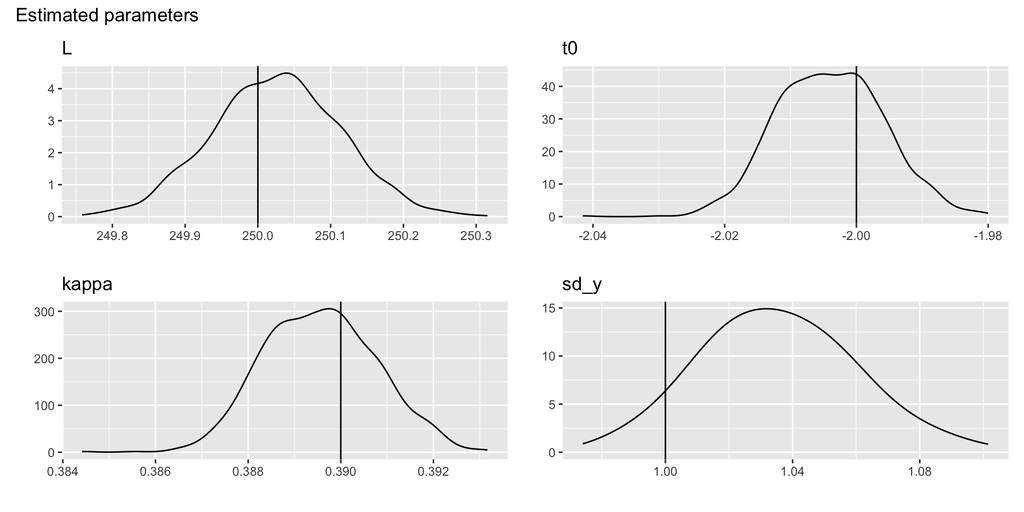

# Lee-Carter Model

## Identifiability Constraints

Model is not unique:

$$\alpha_x + \beta_x \kappa_t = \alpha_x + (c \beta_x)(\kappa_t / c)$$

So we impose constraints:

- $\sum_t \kappa_t = 0$
- $\sum_x \beta_x = 1$

👉 Ensures unique interpretation of parameters

## `inlabru` implementation

```r
cmp_model1 = ~ -1 +
  alpha(age,model= "iid", constr =  F,)+
  beta(age, model= "iid", extraconstr = list(A=A, e=e))+
  kappa(time, model= "rw2", constr = T) +
  spatial(space,  model = "bym2",
          graph = Q_space,
          replicate = as.numeric(as.factor(age2)),
          nrep = length(unique(df$age2))) +
  random(rand2, model = "iid")


formula_model = Y ~    Intercept + subgraphs +  alpha +
  beta * kappa +  spatial + random

likelihood = bru_obs(formula = formula_model,
                      family = "poisson",
                      data = df ,
                      E = E)
result_model = bru(components = cmp_model, likelihood)
```

$$\log(\lambda_{xts}) = \alpha_x + \beta_x \kappa_t + \omega_{sg_x} + z_{xts}$$

## Results

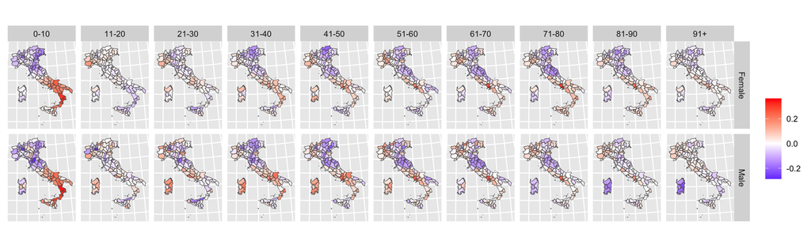

# Accounting for underreporting

## Model for underreported counts

The true (unobserved ) counts
$$\begin{align}
Y^*_i & \sim \text{Poisson}(E_i\lambda_i)\\
\log(\lambda_i) & = \beta_0 + \beta_1x_i + u_i
\end{align}$$

The thinned (observed ) counts

$$\begin{aligned}
Y_i & \sim \text{Poisson}(E_i\lambda_i\pi_i)\\
\log(\lambda_i) & = \beta_0 + \beta_1x_i + u_i\\
\text{logit}(\pi_i)& = \alpha_0 + \alpha_1z_i\\
\end{aligned}$$

The non-linear predictor

$$\begin{align}
Y_i & \sim \text{Poisson}(E_i\lambda_i\pi_i)\\
\eta_i & = \log(\lambda_i\pi_i) \\
& = \beta_0 + \beta_1x_i + u_i + \log(\text{inv.logit}(\alpha_0 + \alpha_1z_i))
\end{align}$$

## `inlabru` implementation

```r
func_probs = function(v,alpha0,alpha1)
{
  aa = alpha0 + alpha1 * v
  return(-log(1+exp(-aa)))
}


cmp =  ~  -1 +
  beta_0(main = 1, model = "linear") +
  beta_1(main = covariate_x, model = "linear")+
  spatial(loc, model = "besag", graph = Q) +

  alpha_0(main = 1, model = "linear",
        mean.linear = b0_mean,
        prec.linear = 1/(b0_sd)^2) +
  alpha_1(main = 1, model = "linear")


formula =  Y_obs  ~
  beta_0 + beta_1 + spatial +
  func(covariate_z, b0, b1)

lik1 = bru_obs("poisson",
            formula = formula,
            data= df,
            E = E)


fit1 <- bru(cmp, lik)
```

**NOTE** we have (quite) informative priors for $\alpha_0$

## Final Notes

- Be careful when using this models!!!
- Think carefully if the model makes sense
- Think carefully about priors
- Check the convergence

```r
bru_options_set(bru_verbose = 2)
```